# Final_Project

Jake Peters

11/30/2021

There are three separate datasets I will be using for this Final Project. The first is a set of daily Crimes reported by the Baltimore government’s police department. This data was found on https://data.baltimorecity.gov/datasets/part1-crime-data. It has reports involving crimes such as larceny, robbery, assault, and many more! It also contains neighborhood data, location, and date/time among others. It is a robust, versatile dataset that enables a lot of flexibility in how one can clean it to make forecasts. I chose to aggregate the data by day, so that all the crimes for each day are added up to a daily crime total for that day. This is in the calendar year of 2021.This is the data that I will try to forecast, specifically attempting to forecast the number of crimes per day based on various regressers.

The next dataset is a set of 911 calls from the common people to the city of Baltimore’s call center. This dataset was found in the same website as the previous dataset, at https://data.baltimorecity.gov/datasets/baltimore::911-calls-for-service-2021/about. This data contains date/time of calls, the district of the call, and the priority of the call, such as High, which would be more dangerous, to Low or non-Emergency, which would not be as crucial to respond. This data will also be aggregated into daily data in 2021, split by priority.

The third dataset I will incorporate into this project is a set of Baltimore weather data from 2021. It involves mintemp, maxtemp, and average temperature for each day from https://www.visualcrossing.com/weather-history/baltimore. I will be using average temperature in this project.

The data I will be using for this project is just on the 2021 year starting in January 2021. It would have been nice to have obtained data over multiple years for the 911 calls data, but unfortunately the baltimore website has dead links for those (missing) datasets. With that being said, let’s read the datasets in and see which priorities are available to choose from.

Next, I cleaned the data, making the date into a proper format, aggregating the total crimes and total calls by priority for each day, and merging the dataset values together via Date.

Here, totalCrimes is the number of Crimes per day reported, totalCalls.x is the total number of 911 calls that day, totalCalls.y is the number of low or non-Emergency calls that day, totalCalls is the number of high or Emergency 911 daily calls, temp is the daily average temperature, and windspeed is the daily average windspeed. Now, we can make scatterplots for some exploratory visualizations of the data to find out which columns can be used to predict the amount of daily crimes in Baltimore.s

```
##
## Call:
## lm(formula = totalCrimes ~ totalCalls.x, data = df)
##
## Residuals:
##    Min     1Q Median     3Q    Max
## -54.35 -11.10  -0.35  11.15  47.87
##
## Coefficients:
##                Estimate Std. Error t value Pr(>|t|)
## (Intercept)  156.318470   7.745069  20.183  < 2e-16 ***
## totalCalls.x  -0.015303   0.002015  -7.594 3.24e-13 ***
## ---
## Signif. codes:  0 '***' 0.001 '**' 0.01 '*' 0.05 '.' 0.1 ' ' 1
##
## Residual standard error: 16.72 on 329 degrees of freedom
## Multiple R-squared:  0.1491, Adjusted R-squared:  0.1466
## F-statistic: 57.67 on 1 and 329 DF,  p-value: 3.241e-13
```

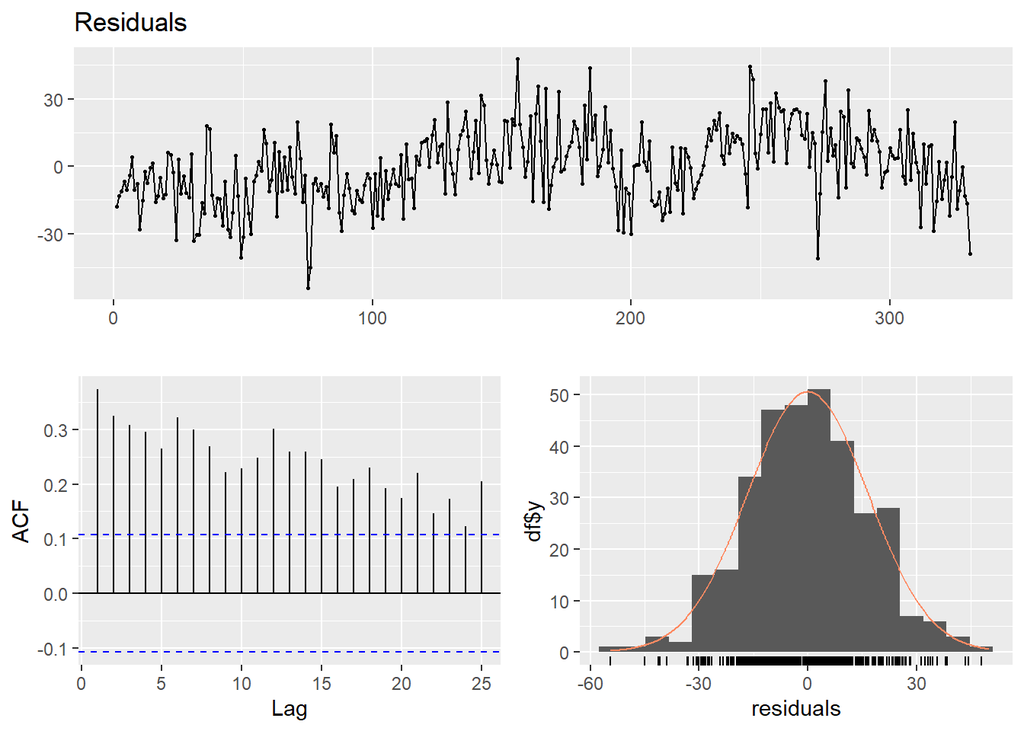

```
##
##  Breusch-Godfrey test for serial correlation of order up to 10
##
## data:  Residuals
## LM test = 96.947, df = 10, p-value = 2.221e-16
```

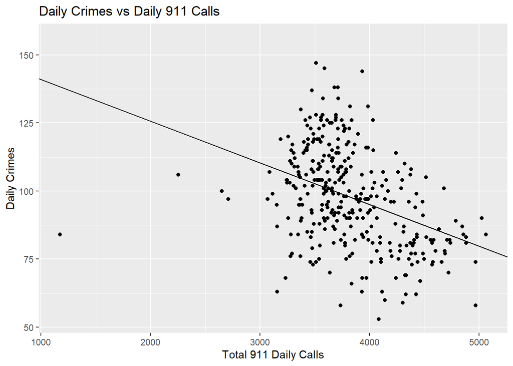

Taking all the calls into consideration, there is actually a negative correlation here. WHaaat?! This threw me off guard. However, when thinking about it more, it seems that there are a lot of low-emergency calls, which do not become crimes. So these are obscuring the important calls.

```
##
## Call:
## lm(formula = totalCrimes ~ totalCalls.y, data = df)
##
## Residuals:
##     Min      1Q  Median      3Q     Max
## -53.542 -10.018   0.024  10.456  44.581
##
## Coefficients:
##                Estimate Std. Error t value Pr(>|t|)
## (Intercept)  156.203439   5.490994   28.45   <2e-16 ***
## totalCalls.y  -0.019540   0.001818  -10.75   <2e-16 ***
## ---
## Signif. codes:  0 '***' 0.001 '**' 0.01 '*' 0.05 '.' 0.1 ' ' 1
##
## Residual standard error: 15.59 on 329 degrees of freedom
## Multiple R-squared:  0.2598, Adjusted R-squared:  0.2576
## F-statistic: 115.5 on 1 and 329 DF,  p-value: < 2.2e-16
```

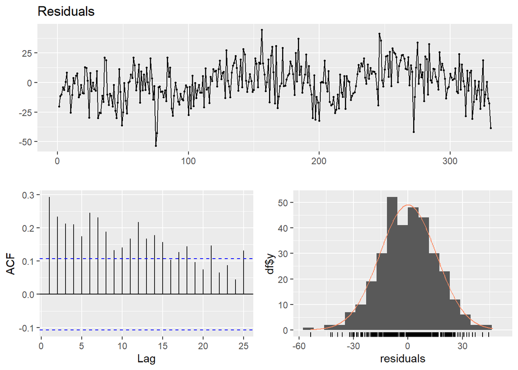

```
##
##  Breusch-Godfrey test for serial correlation of order up to 10
##
## data:  Residuals
## LM test = 63.563, df = 10, p-value = 7.626e-10
```

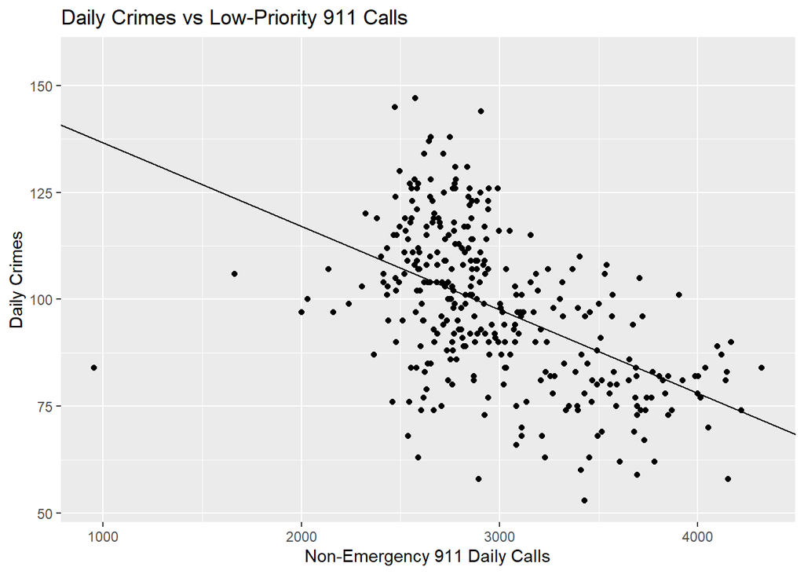

Here there is a more pronounced negative correlation, as the non-Emergency calls are shown to be the set that is truly negatively correlated with daily crimes. There is an R-squared value of .26, which is not amazing, but does explain some variation in the set. This could be used to predict crimes, but the effectiveness remains to be seen.

```
##
## Call:
## lm(formula = totalCrimes ~ totalCalls, data = df)
##
## Residuals:
##     Min      1Q  Median      3Q     Max
## -42.556  -9.626  -0.639   9.552  38.600
##
## Coefficients:
##             Estimate Std. Error t value Pr(>|t|)
## (Intercept) 37.42753    4.17315   8.969   <2e-16 ***
## totalCalls   0.30794    0.02088  14.750   <2e-16 ***
## ---
## Signif. codes:  0 '***' 0.001 '**' 0.01 '*' 0.05 '.' 0.1 ' ' 1
##
## Residual standard error: 14.06 on 329 degrees of freedom
## Multiple R-squared:  0.3981, Adjusted R-squared:  0.3962
## F-statistic: 217.6 on 1 and 329 DF,  p-value: < 2.2e-16
```

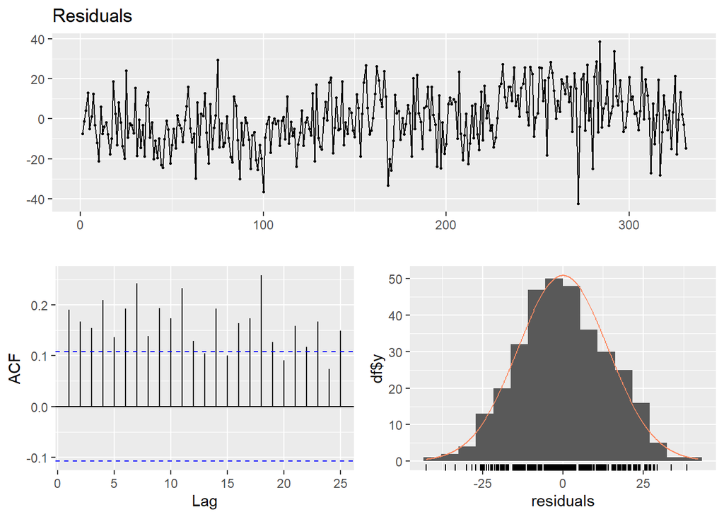

```
##
##  Breusch-Godfrey test for serial correlation of order up to 10
##
## data:  Residuals
## LM test = 50.971, df = 10, p-value = 1.768e-07
```

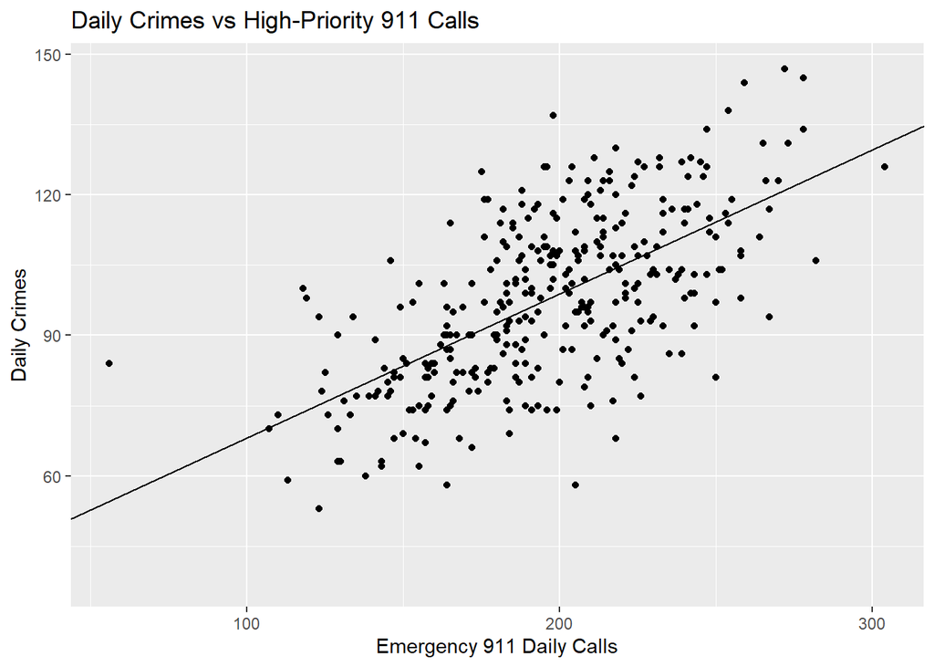

In this plot, it shows a positive correlation between crimes and important 911 calls. This intuitively makes sense, because a lot of those calls are probably about some sort of violent act or theft that is taking place. The R-squared is the best yet, at .39.

```
##
## Call:
## lm(formula = totalCrimes ~ temp, data = df)
##
## Residuals:
##     Min      1Q  Median      3Q     Max
## -42.811  -9.206  -0.857   9.552  44.134
##
## Coefficients:
##             Estimate Std. Error t value Pr(>|t|)
## (Intercept) 59.32195    3.05017   19.45   <2e-16 ***
## temp         0.64225    0.04895   13.12   <2e-16 ***
## ---
## Signif. codes:  0 '***' 0.001 '**' 0.01 '*' 0.05 '.' 0.1 ' ' 1
##
## Residual standard error: 14.68 on 329 degrees of freedom
## Multiple R-squared:  0.3435, Adjusted R-squared:  0.3415
## F-statistic: 172.2 on 1 and 329 DF,  p-value: < 2.2e-16
```

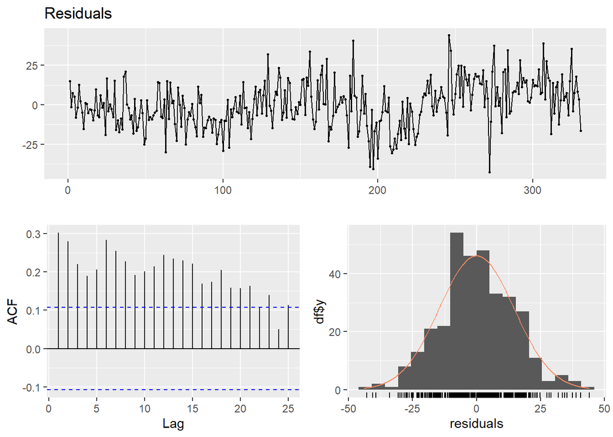

```
##
##  Breusch-Godfrey test for serial correlation of order up to 10
##
## data:  Residuals
## LM test = 64.133, df = 10, p-value = 5.937e-10
```

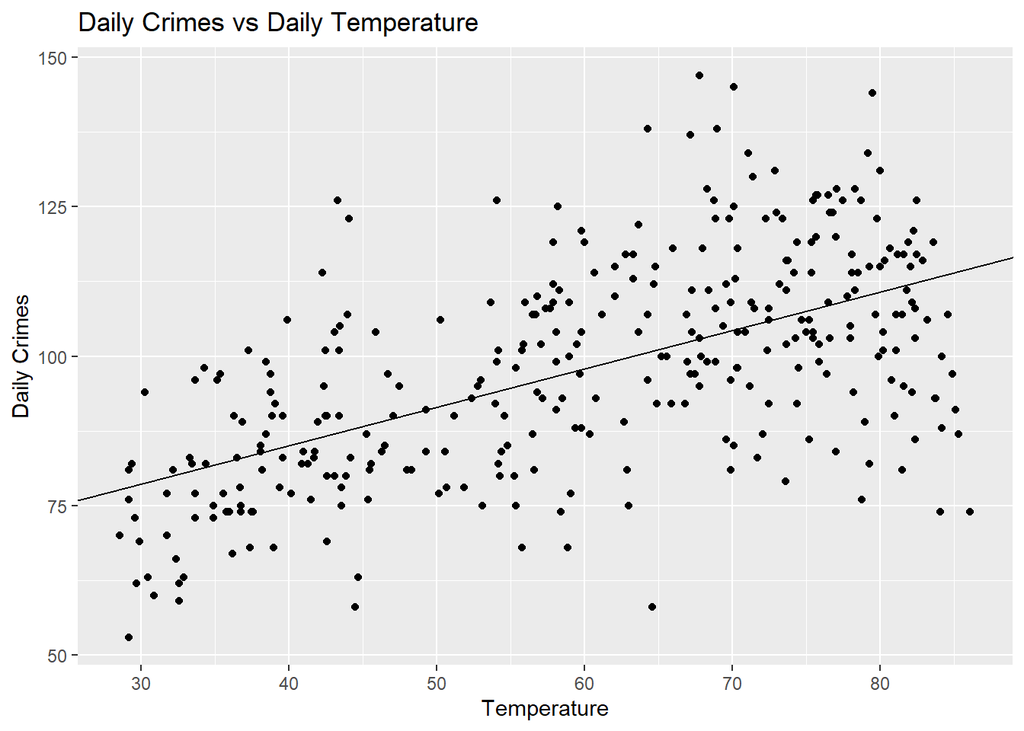

In this plot, the temperature is positively correlated with crimes. This makes sense; criminal activity happens more when it is warmer outside. It could also be a seasonal yearly thing, but because I only have one year of data, I will be ignoring that possibility. We have an R-squared of .34, so better than low-priority, but worse than high-priority.

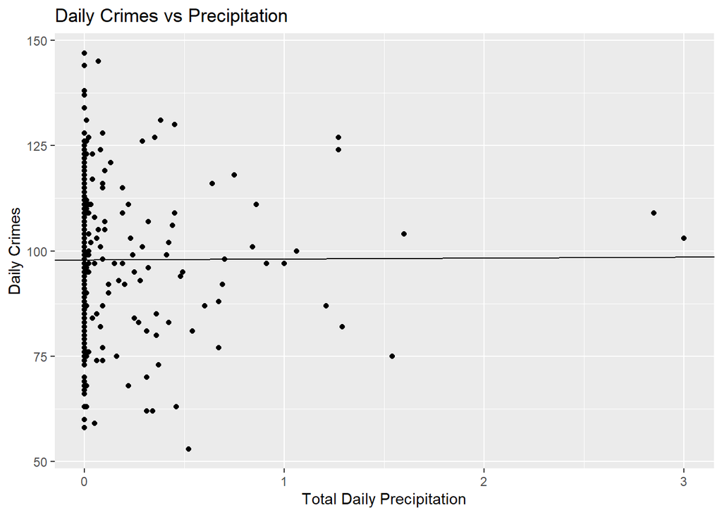

here, the graph is garp. It does not show any sort of correlation. Also, a lot of days have no precip, which would throw off any sort of forecasting I would try without some sort of feature engineering. Therefore, I will not incorporate precip into future forecasts.

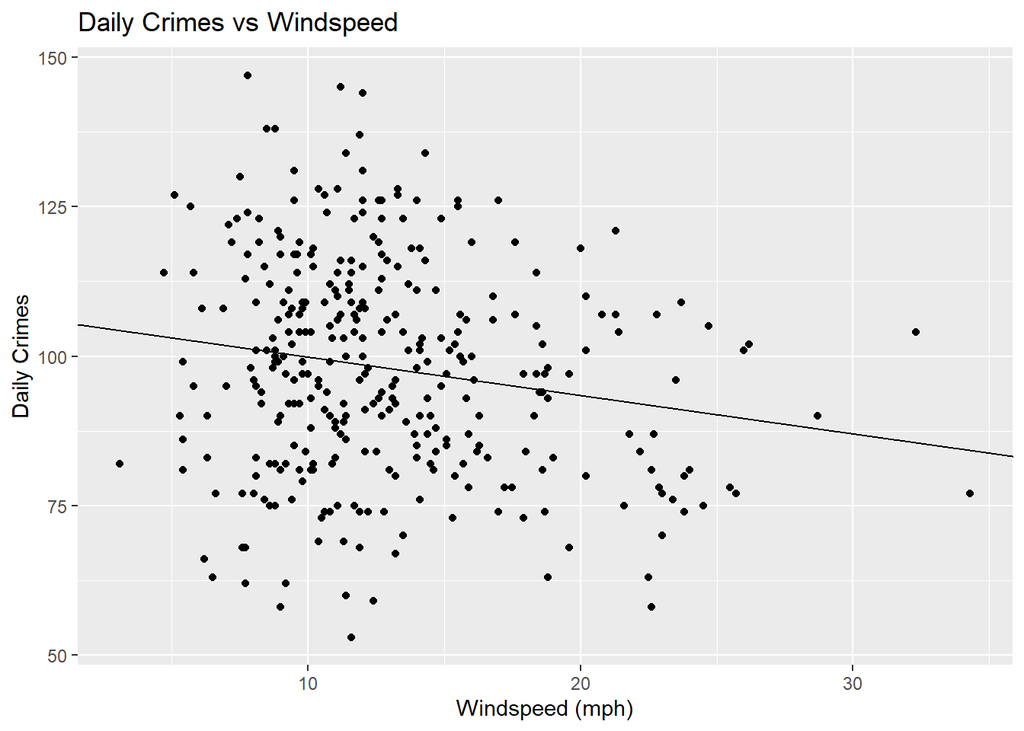

Average daily windspeed actually has a very slight negative correlation with crime, but because it is so small, and we already have temperature to use, I will not incorporate it into future forecasts.

Now let’s look at a bunch of correlation plots to see if there are extra patterns we are missing.

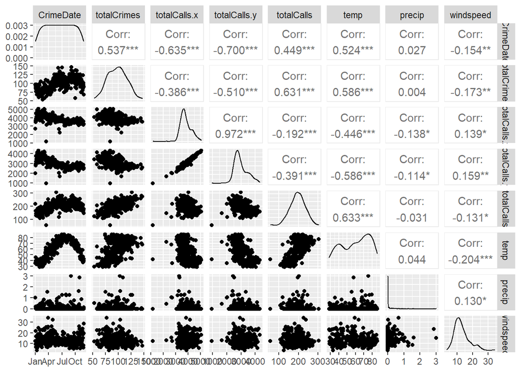

From this overview, it seems we already discussed the strongest correlations out there. Temperature and CrimeDate is the most interesting shape, but it is probably something that has built-in seasonality with yearly data, which is a fact of nature unrelated to crimes. Other promising plots are high-priority calls and low-priority calls, which were already discussed.

Now that we made scatterplots, I am going to transform the crime data using the BoxCox function to see if it helps normalize the variation in the data, if needed.

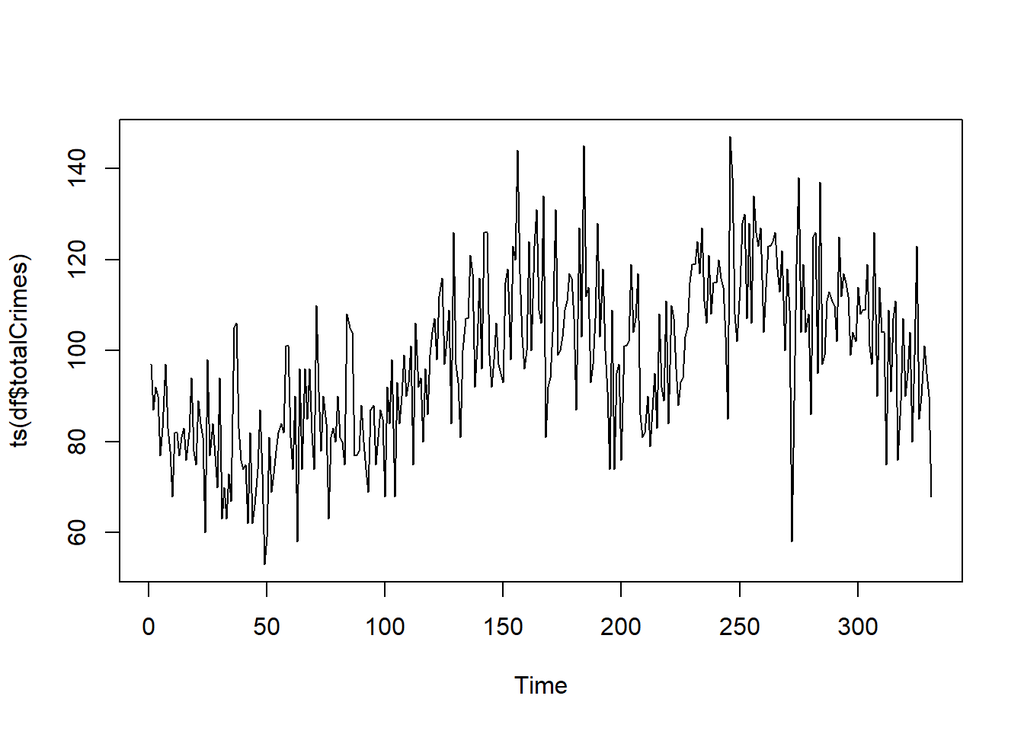

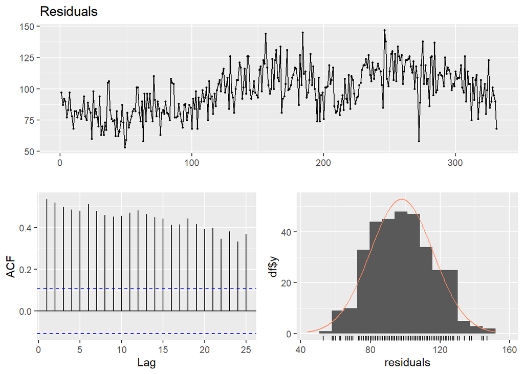

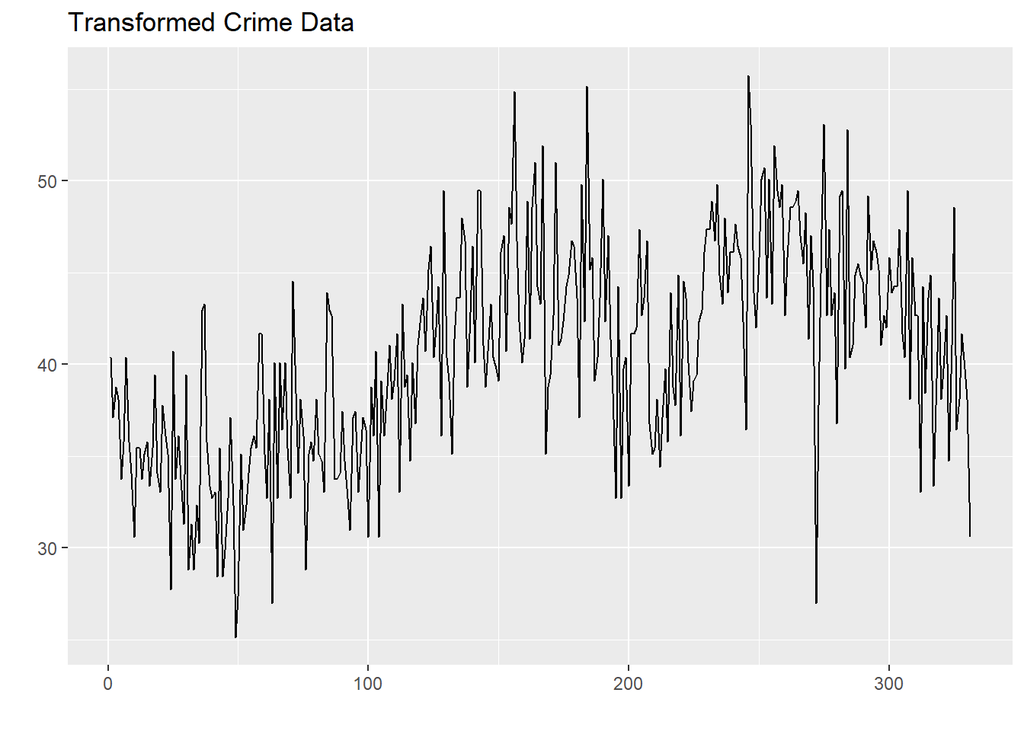

Upon doing a transformation of this data using the BoxCox function, there is not enough change to the resulting data to warrant using a transformed version of the data. Therefore, the original untransformed data will be used.

Now I will split data into training and testing data for ts forecasting validation using 80-20 split. This has ramifications for later on, because the split just happens to coincide with a peak in the data, which is followed by a dip in the 20% of the data. Because our forecasts are trained in the 80%, our forecasts will be off kilter compared to the actual testing data. Later on I will use time series cross validation to try to correct for that.

Now I will try decomposing the crime data to see if there is a seasonal component.

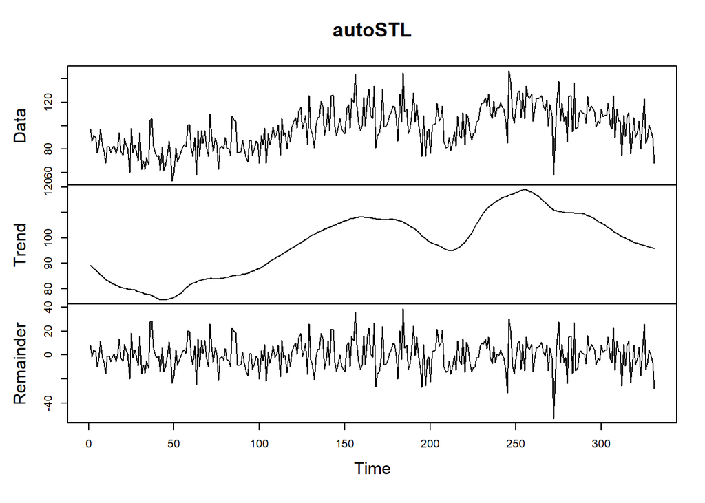

I will do autoarimas of various regressers using the training data to find which variables have lower AICc values/RMSE values.

Let’s make the first forecast. Using all 911 calls.

```
## Series: ts(train$totalCrimes, start = c(2021, 1), freq = 365)
## Regression with ARIMA(1,1,1) errors
##
## Coefficients:
##          ar1      ma1    xreg
##       0.0710  -0.8602  0.0009
## s.e.  0.0721   0.0360  0.0022
##
## sigma^2 estimated as 171.4:  log likelihood=-1048.7
## AIC=2105.39   AICc=2105.55   BIC=2119.68
##
## Training set error measures:
##                     ME     RMSE      MAE       MPE     MAPE MASE         ACF1
## Training set 0.7287619 12.99119 10.40402 -1.039641 11.06767  NaN -0.007488411
```

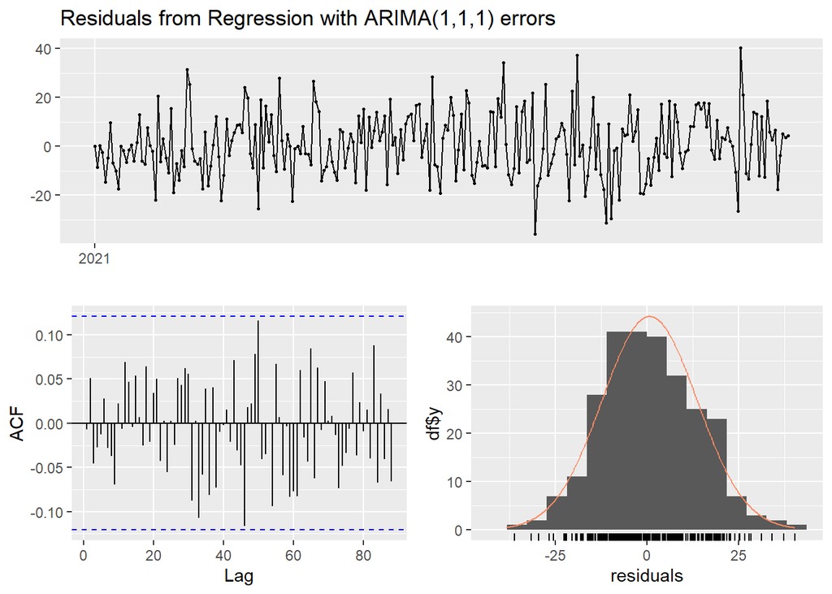

```
##
##  Ljung-Box test
##
## data:  Residuals from Regression with ARIMA(1,1,1) errors
## Q* = 40.592, df = 50, p-value = 0.8262
##
## Model df: 3.   Total lags used: 53
```

1. totalCrimes and high 911 calls

```
## Series: ts(train$totalCrimes, start = c(2021, 1), freq = 365)
## Regression with ARIMA(0,1,1) errors
##
## Coefficients:
##           ma1    xreg
##       -0.8784  0.1786
## s.e.   0.0311  0.0259
##
## sigma^2 estimated as 144.8:  log likelihood=-1027.13
## AIC=2060.27   AICc=2060.36   BIC=2070.99
##
## Training set error measures:
##                     ME     RMSE     MAE        MPE     MAPE MASE       ACF1
## Training set 0.6493394 11.96291 9.70346 -0.9191501 10.38939  NaN 0.02721124
```

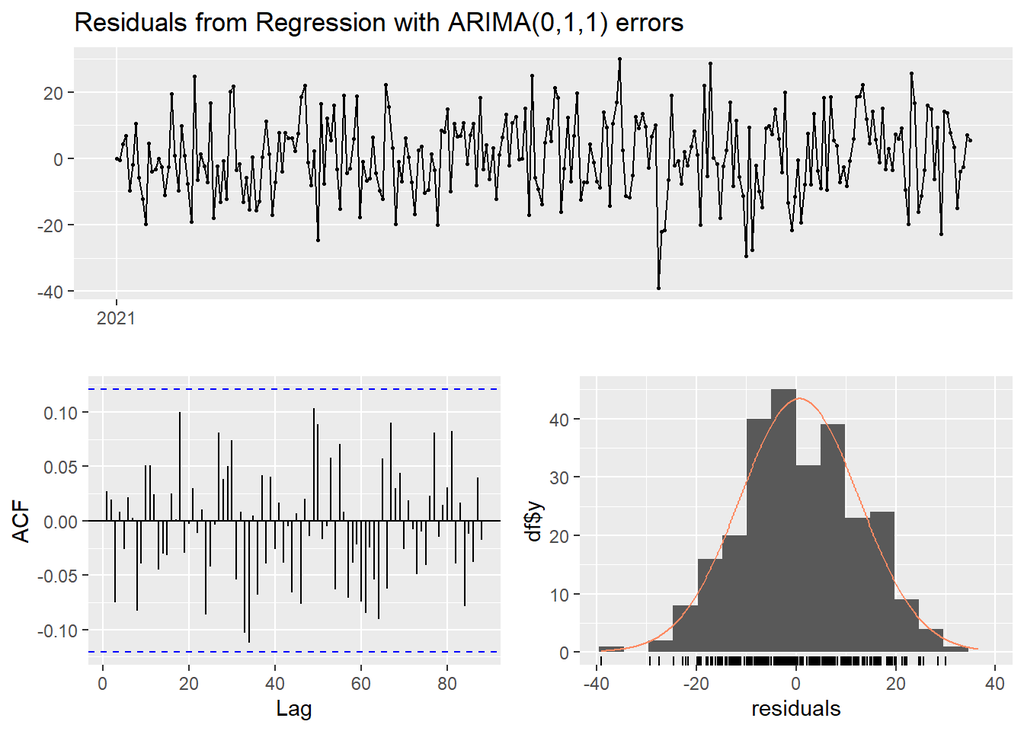

```
##
##  Ljung-Box test
##
## data:  Residuals from Regression with ARIMA(0,1,1) errors
## Q* = 40.725, df = 51, p-value = 0.848
##
## Model df: 2.   Total lags used: 53
```

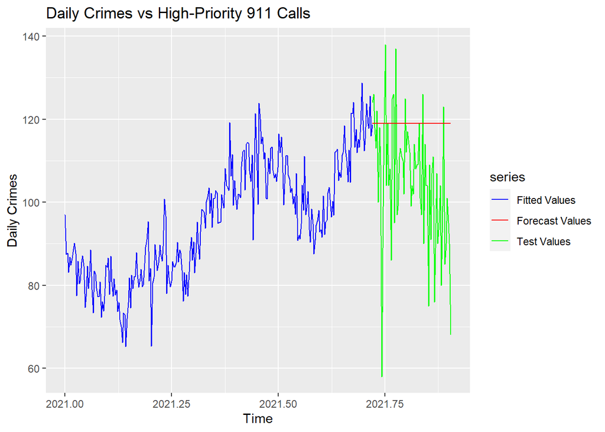

2. totalCrimes and low 911 calls,

```
## Series: ts(train$totalCrimes, start = c(2021, 1), freq = 365)
## Regression with ARIMA(0,1,1) errors
##
## Coefficients:
##           ma1     xreg
##       -0.8432  -0.0024
## s.e.   0.0353   0.0025
##
## sigma^2 estimated as 170.8:  log likelihood=-1048.77
## AIC=2103.54   AICc=2103.63   BIC=2114.25
##
## Training set error measures:
##                     ME     RMSE      MAE       MPE    MAPE MASE       ACF1
## Training set 0.7073885 12.99438 10.39438 -1.051916 11.0636  NaN 0.04371716
```

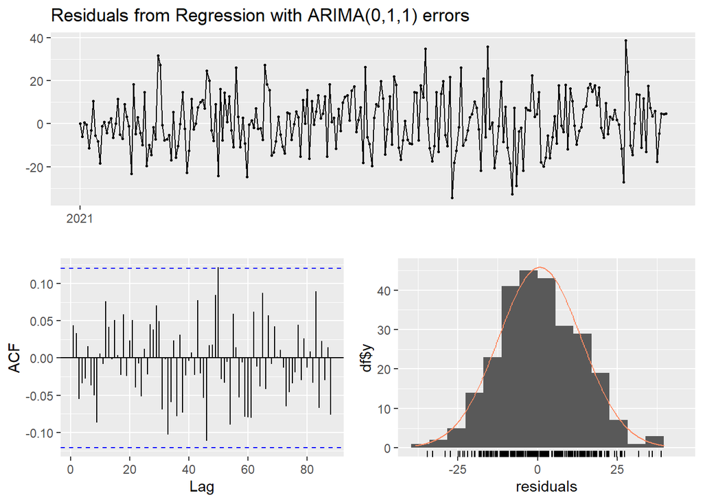

```
##
##  Ljung-Box test
##
## data:  Residuals from Regression with ARIMA(0,1,1) errors
## Q* = 40.309, df = 51, p-value = 0.859
##
## Model df: 2.   Total lags used: 53
```

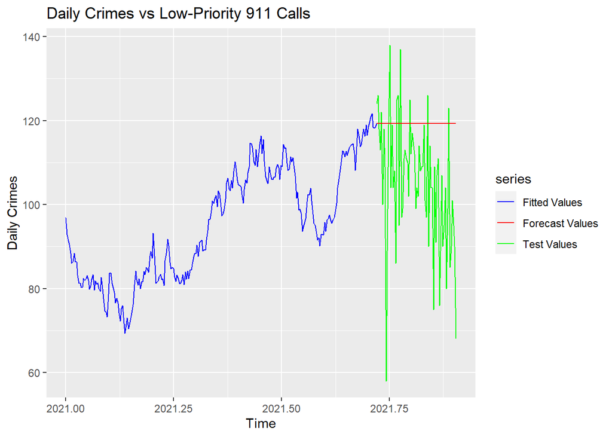

```
## Series: ts(train$totalCrimes, start = c(2021, 1), freq = 365)
## Regression with ARIMA(0,1,1) errors
##
## Coefficients:
##           ma1    xreg
##       -0.8432  0.0766
## s.e.   0.0353  0.0776
##
## sigma^2 estimated as 170.8:  log likelihood=-1048.77
## AIC=2103.54   AICc=2103.63   BIC=2114.25
##
## Training set error measures:
##                     ME     RMSE      MAE       MPE     MAPE MASE       ACF1
## Training set 0.7073035 12.99438 10.39429 -1.052004 11.06351  NaN 0.04372044
```

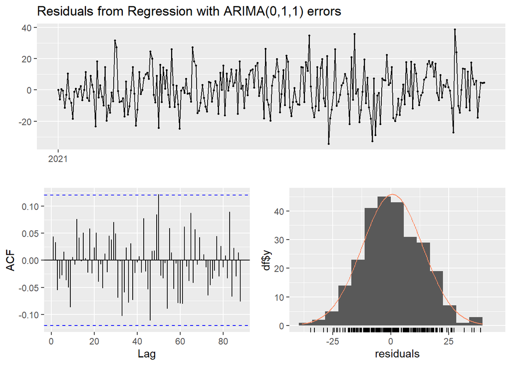

```
##
##  Ljung-Box test
##
## data:  Residuals from Regression with ARIMA(0,1,1) errors
## Q* = 40.31, df = 51, p-value = 0.859
##
## Model df: 2.   Total lags used: 53
```

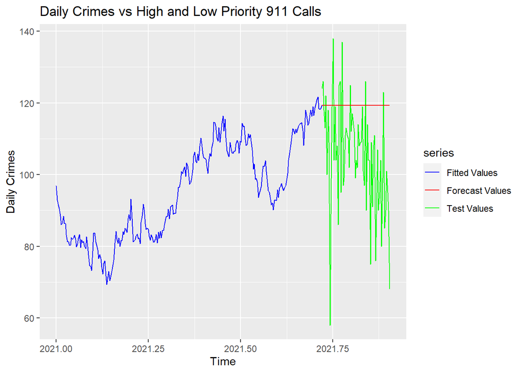

Here there is an RMSE of 20.86, which is slightly worse than the High-priority calls alone, which means that the low-priority data basically gets in the way of producing good forecasts. 4. autoarima with just temperature.

```
## Series: ts(train$totalCrimes, start = c(2021, 1), freq = 365)
## Regression with ARIMA(2,0,1) errors
##
## Coefficients:
##          ar1      ar2      ma1  intercept    xreg
##       1.0274  -0.0524  -0.8485    70.9107  0.4455
## s.e.  0.0774   0.0704   0.0461     9.8677  0.1367
##
## sigma^2 estimated as 166.3:  log likelihood=-1047.44
## AIC=2106.88   AICc=2107.21   BIC=2128.33
##
## Training set error measures:
##                       ME     RMSE      MAE       MPE     MAPE MASE         ACF1
## Training set 0.003358314 12.77155 10.09085 -1.897865 10.78707  NaN -0.001565994
```

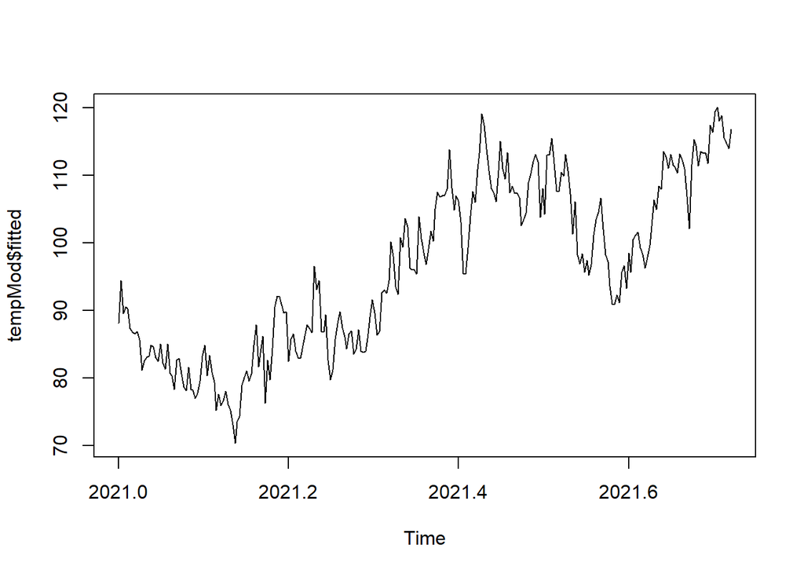

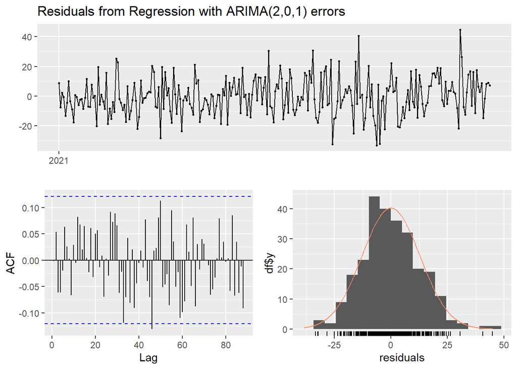

```
##
##  Ljung-Box test
##
## data:  Residuals from Regression with ARIMA(2,0,1) errors
## Q* = 53.967, df = 48, p-value = 0.2569
##
## Model df: 5.   Total lags used: 53
```

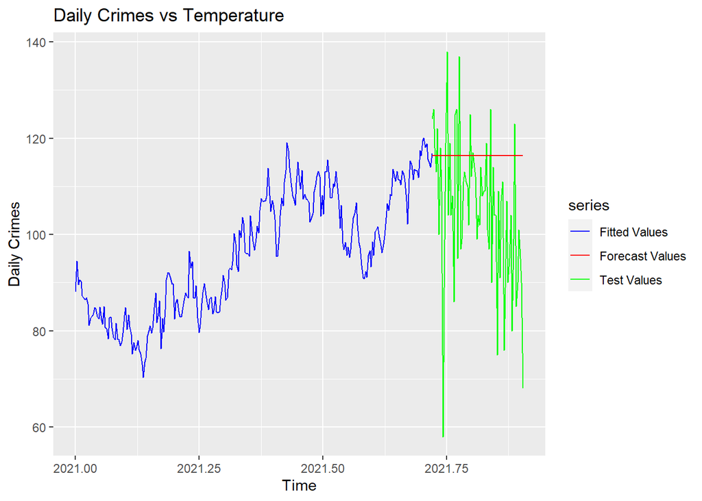

Here, the RMSE is 19.04. In my belief, it has better RMSE values not because it is inherently predicting the data, but rather because the ARIMA is doing different parameters, along with the testing data being drastically different than the ARIMA expects. I am saying that it is basically luck that the ARIMA chose a better model that just happened to coincide more with the future test data out of pure chance. If given a more fortunate split, I believe that the high-priority one would perform the best. I am going to put that to the test right now.

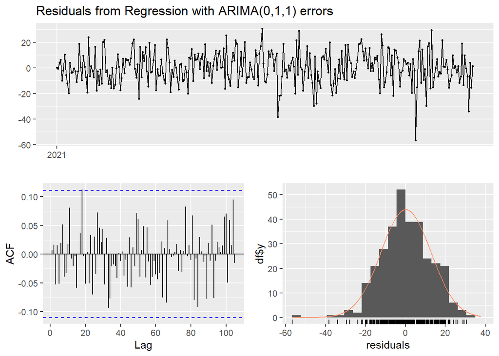

```
##
##  Ljung-Box test
##
## data:  Residuals from Regression with ARIMA(0,1,1) errors
## Q* = 41.281, df = 61, p-value = 0.9751
##
## Model df: 2.   Total lags used: 63
```

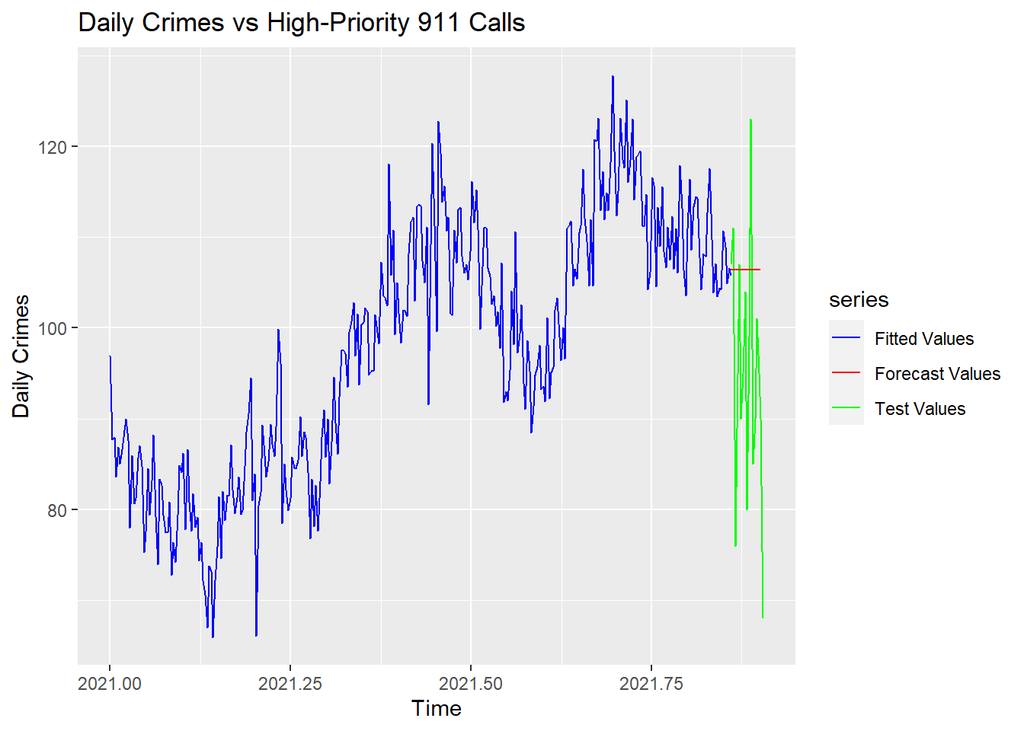

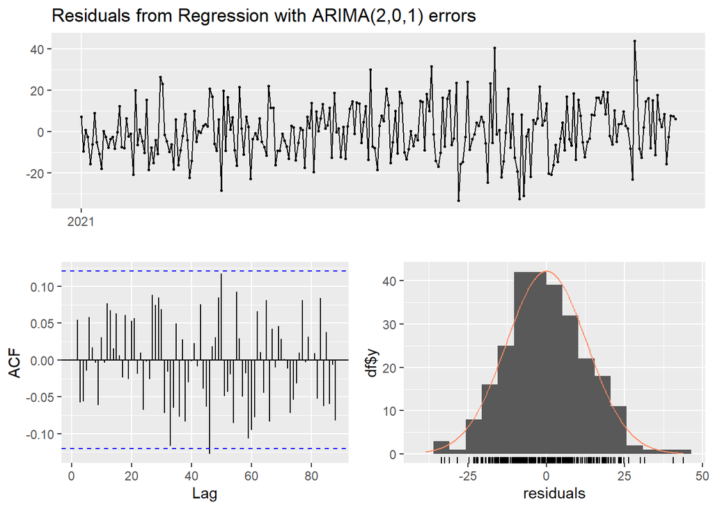

```
##
##  Ljung-Box test
##
## data:  Residuals from Regression with ARIMA(2,0,1) errors
## Q* = 51.635, df = 48, p-value = 0.3337
##
## Model df: 5.   Total lags used: 53
```

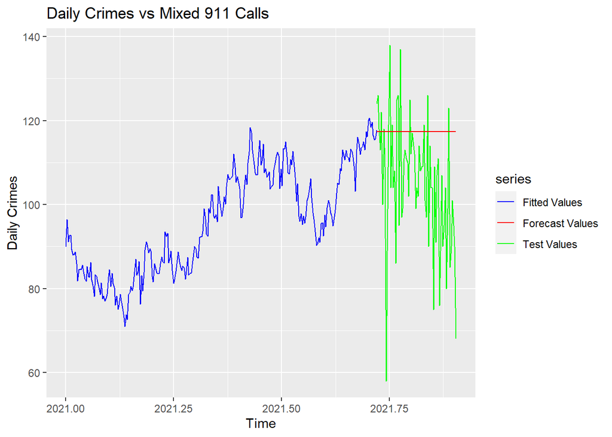

Here, the RMSE is 19.6.

This RMSE is better than the high and low forecasts, but worse than temperature. Again, this is probably pure chance.

Here we have TSCV with Dr. Axvig’s special function to split the data into different windows to validate forecasts.

```
##      h=1      h=2      h=3      h=4      h=5      h=6      h=7      h=8
## 13.51311 13.78183 13.98348 14.29673 14.52885 14.43263 14.51841 14.51794
##      h=9     h=10     h=11     h=12     h=13     h=14     h=15
## 15.00227 14.89911 15.38599 14.76660 15.09429 15.10840 15.29702
```

After trying a few variations of the rmod and mod Arima parameters, the intuitive auto.arima provided parameters for the high-911 calls seem to give the lowest RMSE. Let’s see how this compares to other regressers! But first, lets see if using the whole dataset with an autoarima yields different parameters, and perhaps a better RMSE!

```
## Series: ts(df$totalCrimes, start = c(2021, 1), freq = 365)
## Regression with ARIMA(0,1,1) errors
##
## Coefficients:
##           ma1    xreg
##       -0.8897  0.1711
## s.e.   0.0256  0.0256
##
## sigma^2 estimated as 159.4:  log likelihood=-1304.81
## AIC=2615.62   AICc=2615.7   BIC=2627.02
##
## Training set error measures:
##                      ME     RMSE      MAE       MPE    MAPE MASE         ACF1
## Training set 0.06529109 12.56791 9.921824 -1.623321 10.5881  NaN -0.004681591
```

```
## Series: ts(df$totalCrimes, start = c(2021, 1), freq = 365)
## ARIMA(1,1,1)
##
## Coefficients:
##          ar1      ma1
##       0.0383  -0.8618
## s.e.  0.0638   0.0314
##
## sigma^2 estimated as 181.3:  log likelihood=-1325.94
## AIC=2657.88   AICc=2657.96   BIC=2669.28
##
## Training set error measures:
##                      ME     RMSE      MAE       MPE     MAPE MASE         ACF1
## Training set 0.02885355 13.40457 10.53857 -1.819851 11.20269  NaN -0.001672757
```

```
##      h=1      h=2      h=3      h=4      h=5      h=6      h=7      h=8
## 13.63946 13.84104 14.04151 14.34972 14.58296 14.46134 14.55359 14.51564
##      h=9     h=10     h=11     h=12     h=13     h=14     h=15
## 15.03689 14.96022 15.41767 14.80591 15.12335 15.13282 15.32530
```

```
##      h=1      h=2      h=3      h=4      h=5      h=6      h=7      h=8
## 13.23331 13.56095 13.79956 13.84081 13.79698 14.01920 14.21525 14.36322
##      h=9     h=10     h=11     h=12     h=13     h=14     h=15
## 14.29104 14.28651 14.41154 14.52284 14.85011 15.05356 15.26285
```

```
##      h=1      h=2      h=3      h=4      h=5      h=6      h=7      h=8
## 13.54717 14.13926 14.26832 14.34134 14.74953 15.15043 15.43408 15.46894
##      h=9     h=10     h=11     h=12     h=13     h=14     h=15
## 15.24433 15.40509 15.33870 15.34780 15.65486 16.02368 16.06265
```

Let’s try high-calls and temperature as predictors!

```
##      h=1      h=2      h=3      h=4      h=5      h=6      h=7      h=8
## 73.73606 73.74160 73.74640 73.99420 74.09182 73.61473 73.83989 73.49789
##      h=9     h=10     h=11     h=12     h=13     h=14     h=15
## 73.82335 73.48386 73.68464 72.92948 73.26109 73.78701 73.54538
```

After trying multiple parameter changes on this multiple-regresser model, it seems that the RMSE is much higher. This goes with Dr. Axvig’s lesson 29 notes as well. This makes me wonder if the RMSE values are actually supposed to be that high, or if they are adding the amount to each other erroneously. I do not know the answer to this question, but the RMSE is so much higher that it seems like something is going wrong here. After a few different TSCV tests, it seems that the low-priority values have the lowest RMSE. This is strange; it does not vibe with previous results. Maybe there is something with the negative correlation playing into the data, but I am really not sure. Now let’s do a scenario: what happens if the forecasted temperature in Baltimore is constantly 0 degrees Fehrenheit?

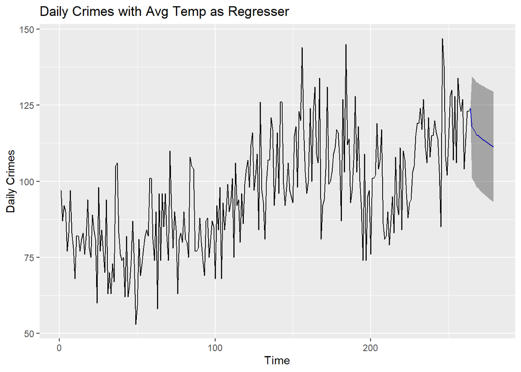

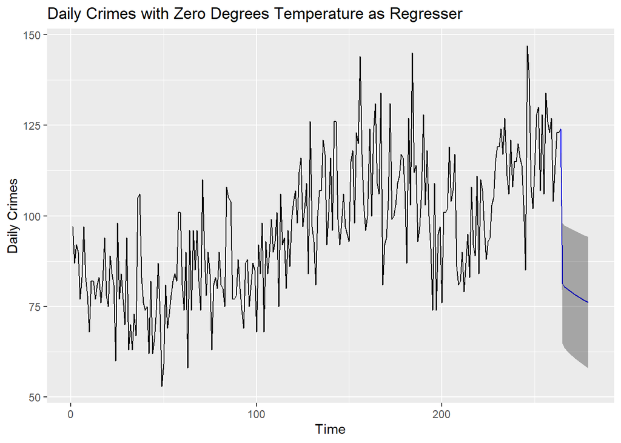

```
## [1] 36.75887
```

How about if it becomes a scorching wasteland of 120 degrees?

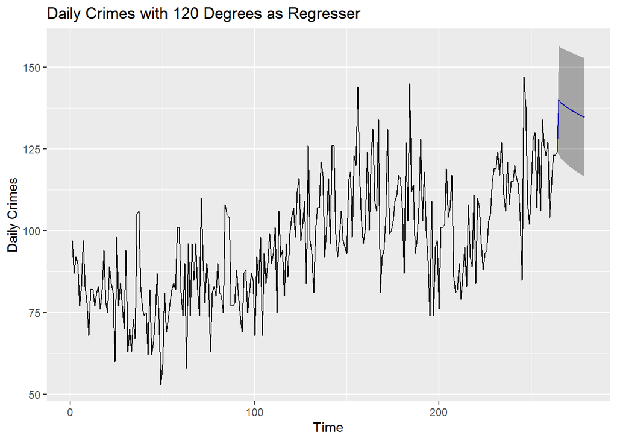

```
## [1] 38.98134
```

Here, the RMSE for a forecasted temperature of zero degrees actually has a better RMSE than a temperature of 120 degrees, by about 2 units. It is not a huge difference, but means that the forecast of zero is closer to the fitted data than a forecast of 120 degrees. So, zero degree temperature days were closer to reality in Baltimore than 120 degree days over the predicted interval for the forecast.

Now, lets look at some scenarios for 911 high/emergency calls.

Let’s use confidence intervals to help forecast; look at the 95th percentile for 911 calls based on our autoarima model and see how it impacts the forecast.

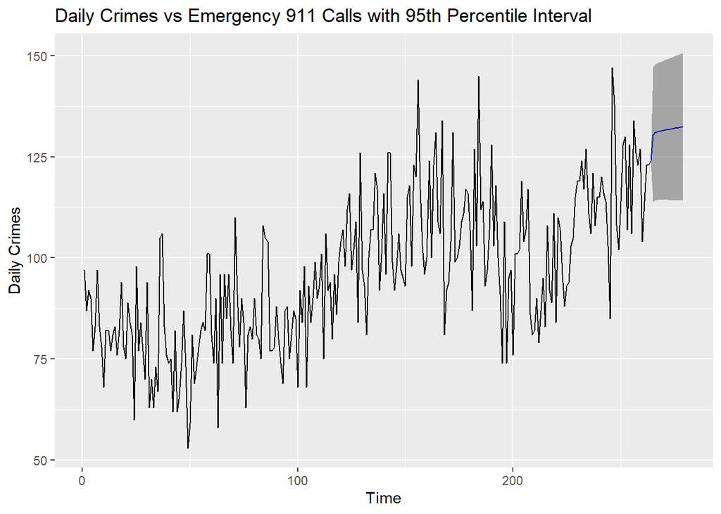

```
## [1] 34.90492
```

```
## [1] 19.59207
```

How bout the 5th percentile of 911 calls? The forecasts will be lower, but what will happen to the RMSE?

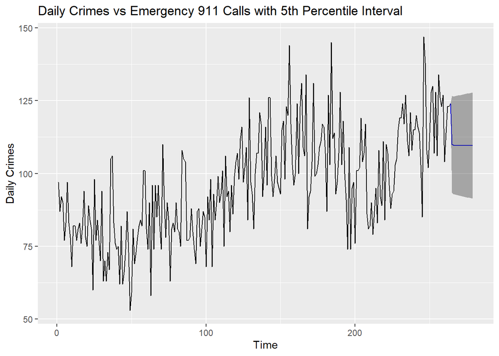

```
## [1] 24.09106
```

Here, the RMSE is quite a bit lower than the upper confidence interval, because the actual crime numbers decrease in the last 20 percent of the dataset.

However, for both cases, in these forecasts, it seems that the high-priority calls data performs better in the high and low intervals than the temperature data at its extremes. This could mean that the high-priority data enables more flexibility in the prediction of the data, which could mean it is the more advantageous predictor after all.

With prediction interval calculations, ARIMA-based intervals seem to be narrow. Per the textbook, this occurs because only the variation in the errors has been taken into account. However, I still think the high-priority call data is the best predictor overall for the crime data, and the last few models bear that out in the numbers, with lower RMSE values for the high-priority data, even though it did not perform the best in earlier models.

From a future chapter, let’s use a neural network model to predict crime data!

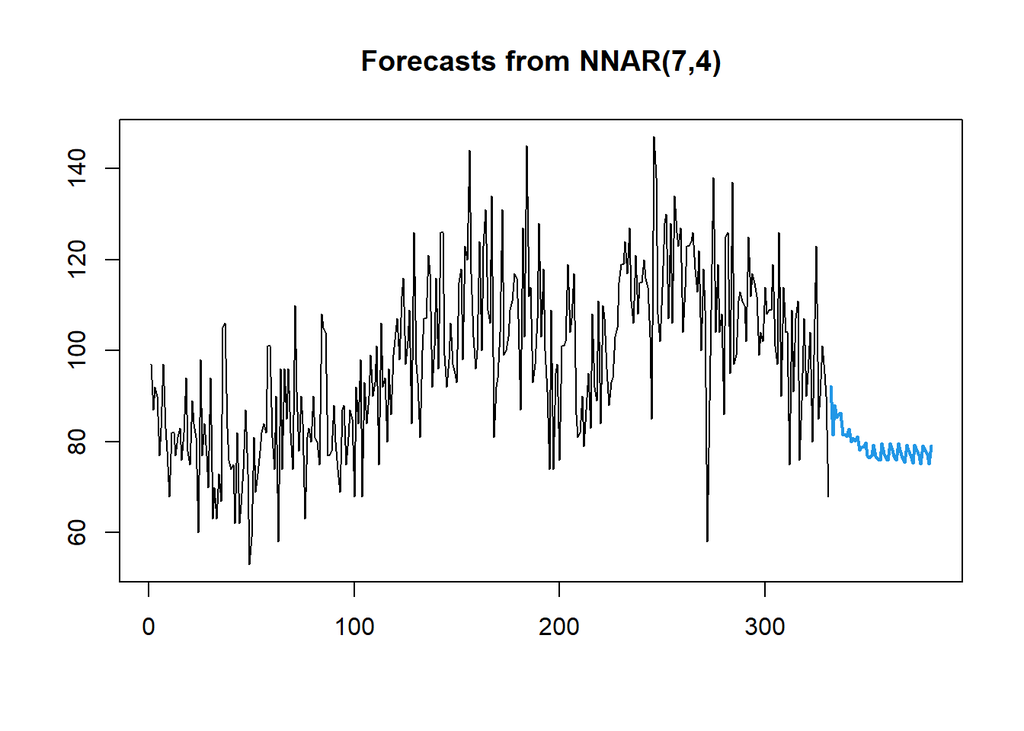

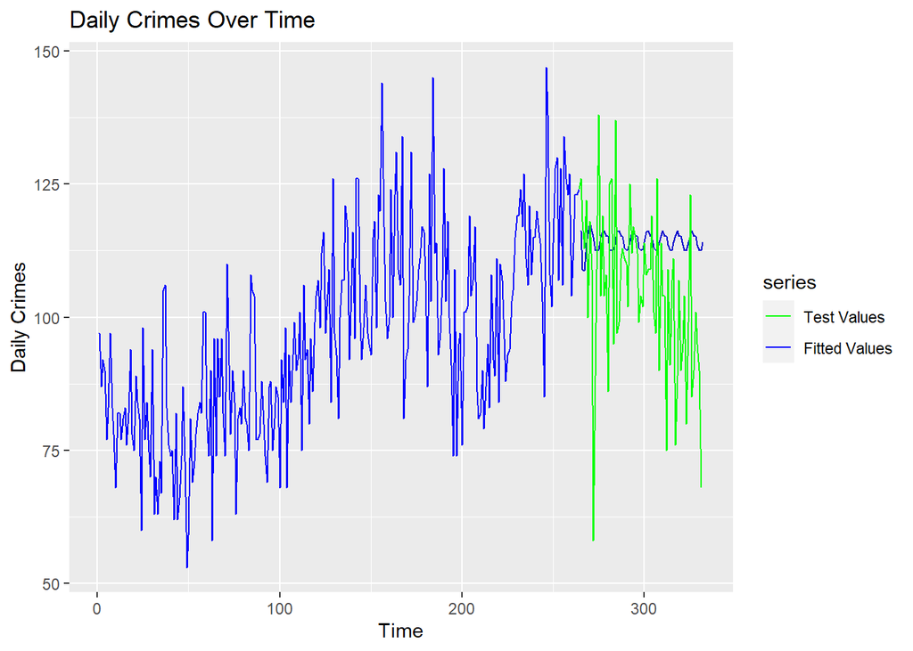

The shape of the forecast values is strange, kind of like a spring tension graph, with the spiral nature of the data. It is similar to a random walk forecast, but with more variation at the first few forecasted values. Now I will simulate a few different paths that could be taken by forecasted plots.

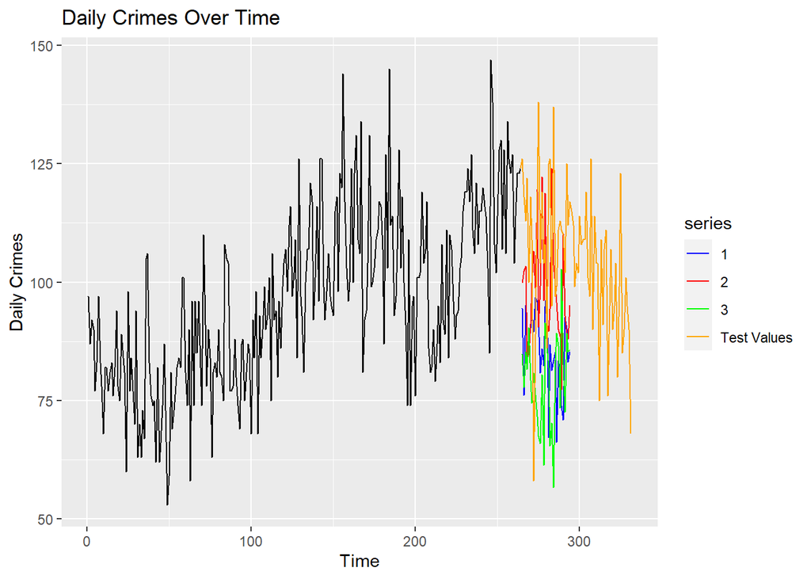

```
## [1] 26.04075
```

```
## [1] 20.59713
```

```
## [1] 31.77588
```

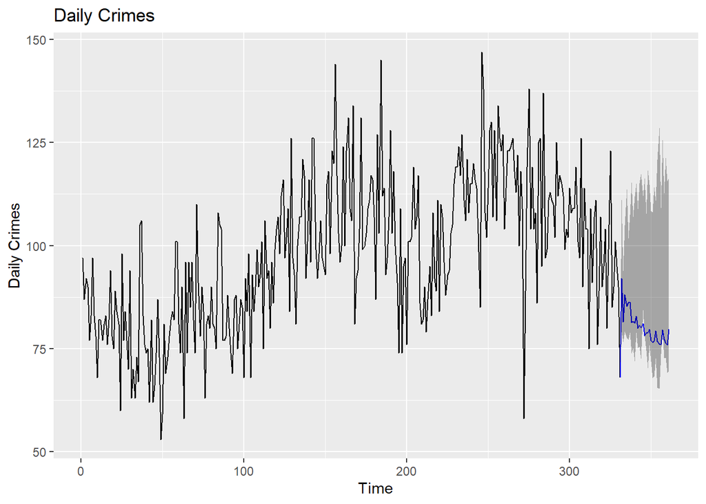

This is a watered-down version of finding prediction intervals for the data. Normally, there would be 1000 simulations, so the npaths argument would be equal to 1000, but to make computation time faster, npaths is equal to 20. I really like the forecast in this case, as it even incorporates some drift along with wavy initial values. Out of all the forecast functions in this project, I think that the neural network one is my favorite. It probably uses some sort of sigmoid function, which I created for Project 2 for prediction, so sigmoids are near and dear to my heart. Also, it actually encapsulates some of the features of the data, like a downward ending trend, and can be simulated however many times someone wants. It seems to be a decent job of making forecasts, as well.

In conclusion, I had mixed results with various tests that I tried. Because the data was not seasonal, it probably took away a lot of potential predictive power that could be accessed with previous datasets. However, in the end, I think that high-priority calls are the best able to predict crime data, followed by temperature in second place, and low-priority calls in third place.